# Mixture models

2024-03-14

## FCS file import

```r
library(flowCore)
```

```r
file.name <- system.file("extdata","0877408774.B08",
                         package="flowCore")
x <- read.FCS(file.name, transformation=FALSE)
summary(x)
```

```
##             FSC-H     SSC-H    FL1-H     FL2-H    FL3-H     FL1-A     FL4-H
## Min.      85.0000   11.0000   0.0000    0.0000   0.0000    0.0000    0.0000
## 1st Qu.  385.0000  141.0000 233.0000  277.0000  90.0000    0.0000  210.0000
## Median   441.0000  189.0000 545.5000  346.0000 193.0000   26.0000  279.0000
## Mean     491.9644  277.9105 439.1023  366.1567 179.7122   34.0766  323.5306
## 3rd Qu.  518.0000  270.0000 610.0000  437.0000 264.0000   51.0000  390.0000
## Max.    1023.0000 1023.0000 912.0000 1023.0000 900.0000 1023.0000 1022.0000
##           Time
## Min.      1.00
## 1st Qu. 122.00
## Median  288.00
## Mean    294.77
## 3rd Qu. 457.50
## Max.    626.00
```

## MASS::fitdistr

The package ‘MASS’ is a part of R, so it does not require installation. This may make it appear to be a first option. The function MASS::fitdistr() will fit a **single** distribution of many sorts. This makes it a great option if the goal is to fit a single distribution.

```r
exprs(x)[1:3,]
```

```
##      FSC-H SSC-H FL1-H FL2-H FL3-H FL1-A FL4-H Time
## [1,]   382    77   618     0   225    55   286    1
## [2,]   628   280   245   431   259     0   371    1
## [3,]  1023   735   699   448   215   143   638    1
```

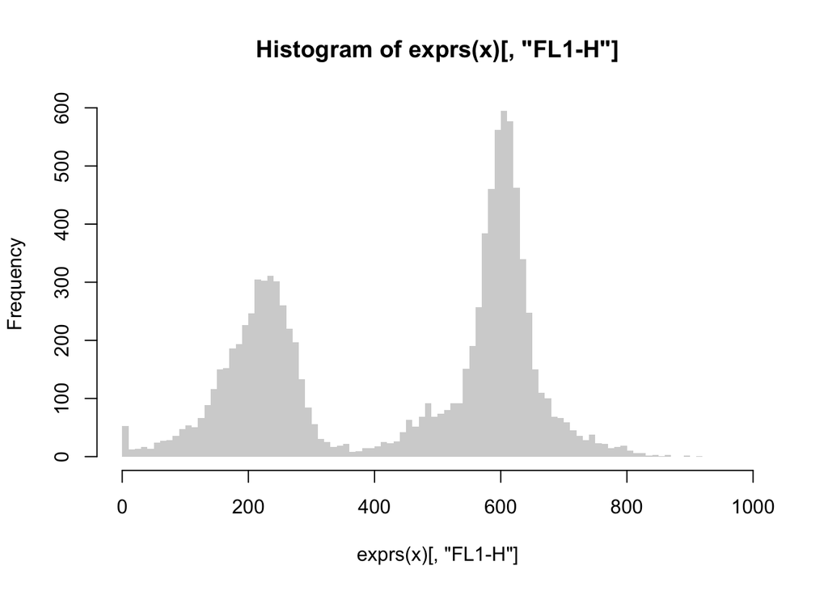

```r
# plot(exprs(x)[, 1])

hist(exprs(x)[, "FL1-H"], breaks = seq(0, 1e3, by = 10), border = NA)
```

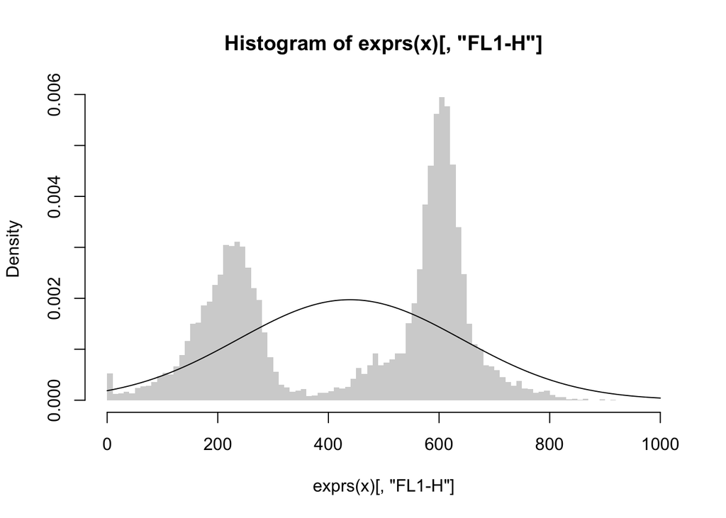

```r
my_params <- MASS::fitdistr(exprs(x)[, "FL1-H"], densfun = "normal")

hist(exprs(x)[, "FL1-H"], freq = FALSE, breaks = seq(0, 1e3, by = 10), border = NA)
my_x <- seq(0, 1e3, by=1)
my_y <- dnorm( my_x, mean = my_params$estimate[1], sd = my_params$estimate[2])
lines(x = my_x, y = my_y)
```

The data appears to be at least bimodal in distribution. A peak a bit above 200, another at just over 600. There may also be a peak near zero. The peak near zero may not be of research interest, but may be worth accounting for. For example, a peak near zero may represent errors that should be accounted for so that they can be separated from expected results.

## Mixture models on CRAN

Mixture models are methodas that fit more than one distribution to the data. This may be multiple distributions of the same form. For example, a mixture model may fit 3 distributions, but they are are **normal distributions**. Some methods may allow for multiple distributions that include different forms of distribution. For example, a mixture model may fit one uniform distribution, 1 Poisson distribution, and 1 normal distributions. Different methods provide different options, so some exploration may be required to find an implementation with the options desired for a specific application.

In the R language, a good starting point when looking for a new method is at CRAN. One strategy I use when looking for a new method is to use the CRAn packages sorted by name page

https://cran.r-project.org/web/packages/available_packages_by_name.html

and use the ‘Find’ method in the browser to query the page for a keyword. On 2024-03-15 I queried this page for ‘mixture model’ and found the following.

- AdaptGauss
- aldvmm
- BAMBI
- batchmix
- bayesanova
- BNPmix
- flexmix Flexible Mixture Modeling
- mclust Gaussian Mixture Modelling for Model-Based Clustering, Classification, and Density Estimation
- MixSemiRob Mixture Models: Parametric, Semiparametric, and Robust
- mixtools Tools for Analyzing Finite Mixture Models
- mixture Mixture Models for Clustering and Classification

These are packages that seemed to stick out to me while I was browsing the 73 matches.

## mixtools

https://cran.r-project.org/web/packages/mixtools/

```r
my_dat <- exprs(x)
my_dat <- as.data.frame(my_dat)
my_dat[1:3, ]
```

```
##   FSC-H SSC-H FL1-H FL2-H FL3-H FL1-A FL4-H Time
## 1   382    77   618     0   225    55   286    1
## 2   628   280   245   431   259     0   371    1
## 3  1023   735   699   448   215   143   638    1
```

```r
library("mixtools")
mm1 <- normalmixEM(my_dat$`FL1-H`, lambda = .5, mu = c(200, 600), sigma = c(60, 70))
```

```
## number of iterations= 12
```

```r
# plot(mm1, density = TRUE, cex.axis = 1.4, cex.lab = 1.4, cex.main = 1.8,
#      main2 = "Time between Old Faithful eruptions", xlab2 = "Minutes")

mm1[c("lambda", "mu", "sigma")]
```

```
## $lambda
## [1] 0.4146154 0.5853846
##
## $mu
## [1] 211.8721 600.0446
##
## $sigma
## [1] 67.96652 64.24531
```

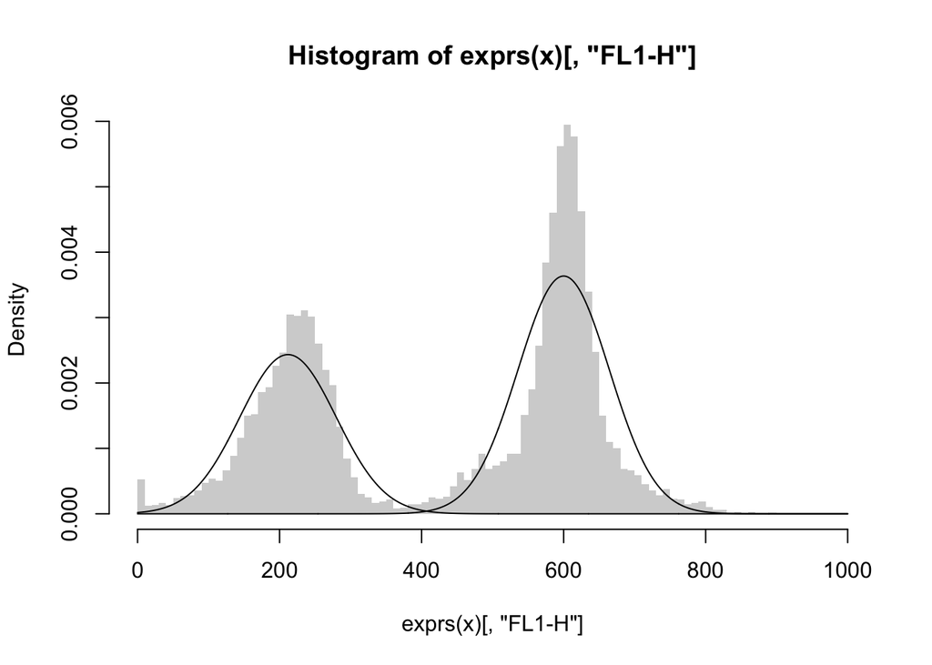

```r
#summary(mm1)

hist(exprs(x)[, "FL1-H"], freq = FALSE, breaks = seq(0, 1e3, by = 10), border = NA)

my_x <- seq(0, 1e3, by=1)
my_y1 <- dnorm( my_x, mean = mm1$mu[1], sd = mm1$sigma[1] ) * mm1$lambda[1]
my_y2 <- dnorm( my_x, mean = mm1$mu[2], sd = mm1$sigma[2] ) * mm1$lambda[2]

lines(x = my_x, y = my_y1)
lines(x = my_x, y = my_y2)
```

```r
mm1 <- normalmixEM(my_dat$`FL1-H`, lambda = .5, mu = c(50, 200, 600), sigma = c(100, 50, 50))
```

```
## number of iterations= 175
```

```r
mm1[c("lambda", "mu", "sigma")]
```

```
## $lambda
## [1] 0.1844950 0.2325989 0.5829061
##
## $mu
## [1] 196.2755 226.6330 600.7415
##
## $sigma
## [1] 93.08680 38.66236 63.45829
```

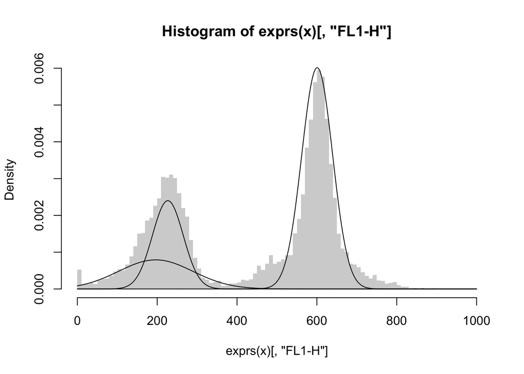

```r
#summary(mm1)

hist(exprs(x)[, "FL1-H"], freq = FALSE, breaks = seq(0, 1e3, by = 10), border = NA)

my_x <- seq(0, 1e3, by=1)
my_y1 <- dnorm( my_x, mean = mm1$mu[1], sd = mm1$sigma[1] ) * mm1$lambda[1]
my_y2 <- dnorm( my_x, mean = mm1$mu[2], sd = mm1$sigma[2] ) * mm1$lambda[2]
my_y3 <- dnorm( my_x, mean = mm1$mu[3], sd = mm1$sigma[2] ) * mm1$lambda[3]
lines(x = my_x, y = my_y1)
lines(x = my_x, y = my_y2)
lines(x = my_x, y = my_y3)
```

```r
#dat_mult <- makemultdata()
#mm1 <- multmixEM(my_dat$`FL1-H`, lambda = 5)
```

## flexmix

https://cran.r-project.org/web/packages/flexmix/

```r
# library("flexmix")
```